# Assignment 2: Factoria

Introduction to Software Engineering (CSSE 1001)  
**Due: 23 October 2026, 15:00 GMT+10**

Author

Course Staff (Communal Document)

Published

September 18, 2026

## Changelog

- 18/09/26:
  - Initial Release.

## Introduction

[Factorio](https://factorio.com/) is a modern software engineering wonder developed by Wube Software. It is a game about constructing automated factories one machine at a time. In this assignment we will be implementing a text based game inspired by Factorio, called Factoria. In Factoria, the player places machines within a factory to produce and transport items, earning funds by transporting these items into rockets. The player may spend funds to buy more machines, but they need to be careful: If they don’t collect enough funds before time runs out, they will be fired!

## Getting Started

Download `a2.zip` from Blackboard. This archive contains the necessary files to start your assignment. Once extracted, the `a2.zip` archive will provide the following files:

- `a2.py`: *This is the only file you will submit* and is where you write your code. *Do not* make changes to any other files.
- `support.py`: *Do not modify or submit this file*, it contains pre-defined constants to use in your assignment. In addition to these, you are encouraged to create your own constants in `a2.py` where possible.
- `display.py`: *Do not modify or submit this file*, it contains additional supporting code for displaying your assignment in a visually appealing manner. You should not need to read and understand the contents of this file.
- `gameplay/`: This folder contains a number of example outputs generated by playing the game using a fully-functional completed solution to this assignment. The purpose of the files in this folder is to help you understand how the game works, and how output should be formatted.
- `levels/` This folder contains a small collection of files used to initialize games of Factoria. In addition to these, you are encouraged to create your own files to help test your implementation where possible.

If you also wish to download this task sheet you must first click `View Fullscreen` at the top of the page. This will open the task sheet in a new browser tab. On this tab, use `Ctrl-P` to print the page, and select `Save to PDF` as the output location. The print button on Blackboard only captures the first two or so pages of this sheet (a limitation of Blackboard beyond our control).

**Caution**

The task sheet may be modified throughout the course of the assignment as issues are identified. These updates will appear online, but will **not** be reflected in a previously downloaded copy. Please regularly check the changelog **online** to ensure you are working with the most up to date version of the task sheet.

## Gameplay

This section provides a high-level overview of gameplay, and is intended to provide you with an idea of the behaviour of a fully completed assignment. Where interactions are not explicitly mentioned in this section, please see the Implementation section.

**Important**

Do not simply implement the behaviour described here using your own structure; you *must* implement the individual functions, classes, and methods described in the Implementation section. Inputs and outputs must match *exactly* what is expected. Refer to the Implementation section, the given examples, and the provided Gradescope tests for clarification on required prompts and outputs.

A game of Factoria take place on a rectangular *Factory* that is constructed from a set of uniformly spaced *Positions*. Positions can be occupied by *Machines*. Each position can hold at most one machine. A Machine is *adjacent* to another machine if it is located at a position immediately above, below, to the left, or to the right of the other machine. The player may add and remove machines from positions in the factory at will. Each machine has a *Cost* which represents how many funds the player must spend to add it to the factory. If the player cannot spend the required funds, the machine cannot be added to the factory.

Factoria is centered on moving *Items* between machines. Each machine can contain at most one item. There are several types of machine in the game, which interact with items as described in Table 1. Each item has a *Value* which represents how many funds the player gains when it is launched in a *Rocket*. Each item also has a set of *Recipes* which determine what items they can be combined with in an *Assembler*, and the resulting new item.

Table 1: Description of the various machines within Factoria.

| Machine | Behavior |
| --- | --- |
| Drill | Spawns new items if it is not holding any. |
| Assembler | Transforms held items based on a second input. |
| Rocket | Launches a held item into space, removing it from the game. |
| Belt | Moves items between two adjacent machines. |

The *Belt* is a machine with special placement rules. When adding a belt to the factory, the player must choose one machine as a source and another as a destination. Both the source and destination machine must be adjacent to the belt. Each machine be the source for at most one belt. A belt’s source cannot be its destination.

In Factoria, the player is given a fixed number of *days* to achieve a target number of funds. Once the player is finished adding and removing machines, they can end the current day. When the player ends a day, each machine in the factory conducts an *action* as outlined in Table 1. The game ends when one of the following occurs:

- The player wins, when after ending a day they have the target number of funds.
- The player loses, when the last day has been ended, and the player does not have the target number of funds.

After starting a game of Factoria, the initial game state is printed to the screen, and the following game loop then occurs:

1. The player is prompted to enter a command using `COMMAND_PROMPT` from `support.py`. Valid commands are given in Table 2.
2. If the player entered a valid command, an action is performed as described in Table 2, and gameplay advances immediately to step 4, skipping step 3.
3. If the player entered an invalid command, they are informed by printing `INVALID_COMMAND_MSG` from `support.py`.
4. The display is updated by printing the current game state to the screen.
5. If the game has not ended, gameplay returns to step 1. Otherwise gameplay advances to step 6.
6. Either `WIN_MSG` or `LOSE_MSG` from `support.py` is printed to the screen informing the player that they won or lost the game as appropriate.
7. The program terminates gracefully.

Table 2: Valid commands and the actions that should be taken. Commands are case insensitive. If the command entered by the user does not exactly match one of the commands in this table (up to case), then no action should be taken. If an attempted action fails, then the player should be informed by printing `INVALID_ACTION_MSG` from `support.py`

| Command | Action to take |
| --- | --- |
| `A [x] [y]`, where `[x]` and `[y]` are integers. | Attempt to add an assembler to position `[x],[y]`. |
| `R [x] [y]`, where `[x]` and `[y]` are integers. | Attempt to add a rocket to position `[x],[y]`. |
| `I [x] [y]`, where `[x]` and `[y]` are integers. | Attempt to add a drill spawning iron to position `[x],[y]`. |
| `C [x] [y]`, where `[x]` and `[y]` are integers. | Attempt to add a drill spawning copper to position `[x],[y]`. |
| `B [s] [t] [x] [y] [d] [c]`, where `[s]`, `[t]`, `[x]`, `[y]`, `[d]`, and `[c]` are integers. | Attempt to add a belt to position `[x],[y]` with source machine at position `[s],[t]` and destination machine at position `[d],[c]`. |
| `X [x] [y]`, where `[x]` and `[y]` are integers. | Attempt to remove the machine located at position `[x],[y]`. |
| `E` | End the current day. |
| `H` | Print `HELP_MSG` from `support.py` |
| `Q` | Gameplay advances immediately to step 7, skipping steps 3-6. |
| `S [f]`, where `[f]` is a filepath | Save current game state to `[F]`. |
| `L [f]`, where `[f]` is a filepath | If `[F]` exists, replace current game state with the one contained in `[F]`. Otherwise print `NO_FILE_MESSAGE` from `support.py` |

## Implementation

**Important**

You are **not** permitted to add any additional import statements to `a2.py`. You must not modify or remove the import statements already provided to you in `a2.py`.

### Required Classes and Methods

This section outlines the classes and methods you are **required** to implement in `a2.py`. Your program must operate *exactly* as specified. In particular, your program’s output must match *exactly* with the expected output. Your program will be marked automatically so minor differences in output (such as whitespace or casing) *will* cause tests to fail resulting in *zero marks* for that test.

You will be following the Apple Model-View-Controller design pattern when implementing this assignment. You have been provided the view component, and are required to implement a number of classes in order to complete the Model and Controller components.

The class diagram in Figure 1 provides an overview of all of the classes you must implement in your assignment, and the basic relationships between them. The details of these classes and their methods are described in depth later in this section. Within Figure 1:

- Orange classes are those provided to you in the supporting files.
- Green classes are abstract classes (superclasses). However, you are not required to enforce the abstract nature of the green classes in their implementation. The purpose of this distinction is to indicate to you that you should only ever instantiate the blue classes in your program (though you should instantiate the green classes to test them before beginning work on their subclasses).
- Blue classes are concrete classes (subclasses).
- Solid arrows indicate inheritance (i.e. the “is-a” relationship).
- Dotted arrows indicate composition (i.e. the “has-a” relationship). An arrow marked with 1-1 denotes that each instance of the class at the base of the arrow contains exactly one instance of the class at the head of the arrow. An arrow marked with 1-N denotes that each instance of the class at the base of the arrow may contain many instances of the class at the head of the arrow.

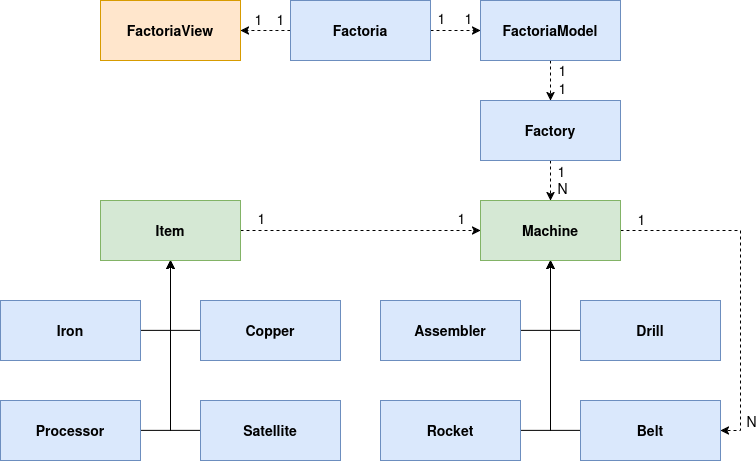

Figure 1: Basic UML diagram for the classes in assignment 2.

**Note**

You are awarded marks for the number of tests passed by your classes when they are tested *independently* of one another. Thus an incomplete assignment with *some* working classes may well be awarded more marks than a complete assignment with faulty classes.

Each class is accompanied with some examples for usage to help you *start* your own testing. You should also test your methods with other values to ensure they operate according to the descriptions.

The rest of this section describes what you must implement in `a2.py` in detail. You should complete the model section before attempting the controller section, ensuring that everything you implement is tested thoroughly, operating correctly, and passes all relevant Gradescope tests.

### Model

The following are the classes and methods you are required to implement as part of the model. You should develop the classes in the order in which they are described in this section and test each one (including on Gradescope) before moving on to the next class. Functionality marks are awarded for each class (and each method) that work correctly. You will likely do very poorly if you submit an attempt at every class, where no classes work according to the description. Some classes require significantly more time to implement than others. The marks allocated to each class are not necessarily an indication of their difficulty or the time required to complete them. You are allowed (and encouraged) to write additional helper methods for any class to help break up long methods, but these helper methods MUST be private (i.e. they must be named with a leading underscore).

#### Task 1 `Item()`

`Item` is an abstract class from which all instantiated types of items inherit. This class provides default item behavior, which can be inherited or overridden by specific types of items. All items are represented by a single character identifier, and possess a fixed integer value. Items also possess a fixed set of valid recipes. Recipes are depicted using a dictionary, where keys are the single character identifier of item that this item can be combined with, and values are the single character identifier of the resulting item.

Abstract items are represented by the symbol `T`, have value `0`, and have no valid recipes.

`Item` must implement the following methods:

- `__init__(self)`  
  Instantiate a new item.
- `__str__(self) -> str`  
  Returns the identifier that represents this item.
- `__repr__(self) -> str`  
  Returns a string which could be copied and pasted into a REPL to construct a new instance identical to self.
- `get_value(self) -> int`  
  Returns this item’s value.
- `get_recipes(self) -> dict[str, str]`  
  Returns the valid recipes for this item.

**Tip**

You may inherit the default `__init__` method if you do not require it.

Example:

```python
>>> thing = Item()
>>> thing
```

```
Item()
```

```python
>>> str(thing)
```

```
'T'
```

```python
>>> thing.get_value()
```

```
0
```

```python
>>> thing.get_recipes()
```

```
{}
```

#### Task 2 `Copper(Item)`

A metal essential in the construction of electronics. Copper is represented by the symbol `C`, has a value of `2`, and can be combined with iron to produce a processor.

Example:

```python
>>> thing = Copper()
>>> thing
```

```
Copper()
```

```python
>>> str(thing)
```

```
'C'
```

```python
>>> thing.get_value()
```

```
2
```

```python
>>> thing.get_recipes()
```

```
{'I': 'P'}
```

#### Task 3 `Iron(Item)`

An abundant metal required to make casings. Iron is represented by the symbol `I`, and has a value of `1`. Iron can be combined with copper to produce a processor, or can be further combined with a processor to produce a satellite.

Example:

```python
>>> thing = Iron()
>>> thing
```

```
Iron()
```

```python
>>> str(thing)
```

```
'I'
```

```python
>>> thing.get_value()
```

```
1
```

```python
>>> thing.get_recipes()
```

```
{'C': 'P', 'P': 'S'}
```

#### Task 4 `Processor(Item)`

A valuable piece of hardware. Processors are represented by the symbol `P`, have a value of `5`, and can be combined with iron to produce a satellite.

Example:

```python
>>> thing = Processor()
>>> thing
```

```
Processor()
```

```python
>>> str(thing)
```

```
'P'
```

```python
>>> thing.get_value()
```

```
5
```

```python
>>> thing.get_recipes()
```

```
{'I': 'S'}
```

#### Task 5 `Satellite(Item)`

People pay a lot of money to get satellites into space. Satellites are represented by the symbol `S` and have a value of `10`. Satellites are the end goal of production and thus cannot be combined with any other item.

Example:

```python
>>> thing = Satellite()
>>> thing
```

```
Satellite()
```

```python
>>> str(thing)
```

```
'S'
```

```python
>>> thing.get_value()
```

```
10
```

```python
>>> thing.get_recipes()
```

```
{}
```

#### Task 6 `Machine()`

`Machine` is an abstract class from which all instantiated types of machine inherit. This class provides default machine behavior, which can be inherited or overridden by specific types of machine. All machines are represented by a single character identifier, and have a fixed integer cost. Any given machine may also hold a single item, and has an action that it can perform. Items cannot be added to a tile if it is currently holding one.

Abstract machines are represented by the symbol `M` and have cost `0`. Abstract machines do nothing when they perform their action.

**Tip**

The `tick` method of the `Machine` class will do nothing but pass. This behavior will be overridden by subclasses.

`Machine` must implement the following methods:

- `__init__(self, held: Item | None)`  
  Instantiate a new machine holding the given item, or holding no item if `held` is `None`.
- `__str__(self) -> str`  
  Returns the identifier that represents this machine if it is holding no item. Otherwise returns the identifier that represents the item it is holding.
- `__repr__(self) -> str`  
  Returns a string which could be copied and pasted into a REPL to construct a new instance identical to self.
- `get_type(self) -> str`  
  Returns the identifier that represents this machine.
- `get_cost(self) -> int`  
  Returns the cost of this machine.
- `check_item(self) -> Item | None`  
  Returns the item this machine is holding, or `None` if it is not holding one.
- `add_item(self, item: Item) -> bool`  
  Attempts to add the given item to the machine. Returns True if (and only if) an item was added to the machine.
- `remove_item(self) -> Item | None`  
  Removes and returns the item this machine is holding, or returns `None` if it is not holding any.
- `tick(self)`  
  Performs this machine’s action.

Example:

```python
>>> machine = Machine(None)
>>> machine
```

```
Machine(None)
```

```python
>>> str(machine)
```

```
'M'
```

```python
>>> machine.tick() # Does nothing
>>> machine
```

```
Machine(None)
```

```python
>>> machine = Machine(Copper())
>>> machine
```

```
Machine(Copper())
```

```python
>>> str(machine)
```

```
'C'
```

```python
>>> machine.get_type()
```

```
'M'
```

```python
>>> machine.get_cost()
```

```
0
```

```python
>>> machine.check_item()
```

```
Copper()
```

```python
>>> machine.add_item(Iron()) # Already occupied
```

```
False
```

```python
>>> machine.check_item()
```

```
Copper()
```

```python
>>> machine.remove_item()
```

```
Copper()
```

```python
>>> machine.check_item()
```

```python
>>> machine.remove_item() # Nothing to remove
```

```python
>>> machine.add_item(Iron())
```

```
True
```

```python
>>> machine.check_item()
```

```
Iron()
```

#### Task 7 `Assembler(Machine)`

An `Assembler` is a machine that combines items based on their recipes. Assemblers are represented by the symbol `A` and have cost `5`.

When adding an item to an assembler already holding an item, it does not automatically fail. Instead, if the incoming item is a valid recipe input for the held item, the held item is replaced with the corresponding recipe output. This combination is done when an item is added to the assembler, and so these machines don’t have a regular action.

Example:

```python
>>> machine = Assembler(None)
>>> machine
```

```
Assembler(None)
```

```python
>>> machine.tick() # Does nothing
>>> machine
```

```
Assembler(None)
```

```python
>>> str(machine)
```

```
'A'
```

```python
>>> machine.get_type()
```

```
'A'
```

```python
>>> machine.get_cost()
```

```
5
```

```python
>>> machine.add_item(Iron())
```

```
True
```

```python
>>> machine.check_item()
```

```
Iron()
```

```python
>>> machine.add_item(Iron()) # Invalid Recipe
```

```
False
```

```python
>>> machine.check_item()
```

```
Iron()
```

```python
>>> machine.add_item(Copper())
```

```
True
```

```python
>>> machine.check_item()
```

```
Processor()
```

```python
>>> str(machine)
```

```
'P'
```

#### Task 8 `Drill(Machine)`

A `Drill` is a machine that extracts items from the ground to use in the factory. Drills are represented by the symbol `D` and have cost `2`.

When a drill takes its action, it spawns a fixed item type if it is not currently holding an item. Drills are designed as output only, and thus adding items to a drill always fails.

To support this extended functionality, the `__init__` method of `Drill` takes in an additional argument. In addition to the `Machine` methods that must be supported, `Drill` must implement the following methods:

- `__init__(self, held: Item | None, spawn_type: str)`  
  Instantiate a new drill holding the given item, or holding no item if `held` is `None`. This new drill spawns items of the specified type.
- `get_spawn_type(self) -> str`  
  Returns the identifier that represents the type of item spawned by this drill.

Example:

```python
>>> machine = Drill(Iron(), 'P')
>>> machine
```

```
Drill(Iron(), 'P')
```

```python
>>> str(machine)
```

```
'I'
```

```python
>>> machine.get_type()
```

```
'D'
```

```python
>>> machine.get_cost()
```

```
2
```

```python
>>> machine.get_spawn_type()
```

```
'P'
```

```python
>>> machine.check_item()
```

```
Iron()
```

```python
>>> machine.tick() # Machine full.
>>> machine
```

```
Drill(Iron(), 'P')
```

```python
>>> machine.check_item()
```

```
Iron()
```

```python
>>> machine.remove_item()
```

```
Iron()
```

```python
>>> machine.check_item()
```

```python
>>> machine.add_item(Processor())
```

```
False
```

```python
>>> machine.check_item()
```

```python
>>> machine.tick()
>>> machine
```

```
Drill(Processor(), 'P')
```

```python
>>> machine.check_item()
```

```
Processor()
```

#### Task 9 `Rocket(Machine)`

A `Rocket` represents the silo for a cargo rocket. Rockets are represented by the symbol `R` and have cost `20`.

When a rocket takes an action it launches its held item into the great beyond, removing it from the game. When an item is removed from the game in this manner, the rocket gains funds equal to the items value. These funds can then be collected by the player.

To support this extended functionality, the `__init__` method of `Rocket` takes in an additional argument. In addition to the `Machine` methods that must be supported, `Rocket` must implement the following methods:

- `__init__(self, held: Item | None, funds: int)`  
  Instantiate a new rocket with the designated funds and holding the given item, or holding no item if `held` is `None`.
- `check_funds(self) -> int`  
  Returns how many funds this rocket currently has.
- `collect_funds(self) -> int`  
  Returns this rocket’s funds, resetting the rocket to 0 funds.

Example:

```python
>>> machine = Rocket(Copper(), 67)
>>> machine
```

```
Rocket(Copper(), 67)
```

```python
>>> str(machine)
```

```
'C'
```

```python
>>> machine.get_type()
```

```
'R'
```

```python
>>> machine.get_cost()
```

```
20
```

```python
>>> machine.check_funds()
```

```
67
```

```python
>>> to_yeet = machine.check_item()
>>> to_yeet.get_value()
```

```
2
```

```python
>>> machine.tick()
>>> machine
```

```
Rocket(None, 69)
```

```python
>>> machine.check_item()
```

```python
>>> machine.check_funds()
```

```
69
```

```python
>>> machine.tick() # Nothing to launch
>>> machine
```

```
Rocket(None, 69)
```

```python
>>> machine.check_item()
```

```python
>>> machine.check_funds()
```

```
69
```

```python
>>> machine.collect_funds()
```

```
69
```

```python
>>> machine.check_funds()
```

```
0
```

#### Task 10 `Belt(Machine)`

The humble `Belt` is the lifeblood of a factory. The belt transports items between a source machine and a destination machine. Belts are represented by the symbol `B` and have cost `1`.

When a belt takes an action, it first attempts to move its held item into the destination machine, it then attempts to move the held item of the source machine into itself.

To support this extended functionality, the `__init__` method of `Belt` takes in two additional arguments. In addition to the `Machine` methods that must be supported, `Belt` must implement the following methods:

- `__init__(self, held, source: Machine | None, destination: Machine | None)`  
  Instantiate a new belt holding the given item, or holding no item if `held` is `None`. The belt has the given source machine, or no source if `source` is `None`. The belt has the given destination machine, or no destination if `destination` is `None`.
- `get_source(self) -> Machine | None`  
  Returns this belt’s source machine, or `None` if it does not have one.
- `set_source(self, new_source: Machine | None)`  
  Sets this belt’s source to the given machine, or removes the belt’s source if `new_source` is `None`.
- `get_destination(self) -> Machine | None`  
  Returns this belt’s destination machine, or `None` if it does not have one.
- `set_destination(self, new_destination: Machine | None)`  
  Sets this belt’s destination to the given machine, or removes the belt’s destination if `new_destination` is `None`.

Example:

```python
>>> yeeter = Assembler(Copper())
>>> yeeter
```

```
Assembler(Copper())
```

```python
>>> yoinker = Assembler(None)
>>> yoinker
```

```
Assembler(None)
```

```python
>>> belt = Belt(None, yeeter, yoinker)
>>> belt
```

```
Belt(None, Assembler(Copper()), Assembler(None))
```

```python
>>> str(belt)
```

```
'B'
```

```python
>>> belt.get_type()
```

```
'B'
```

```python
>>> belt.get_cost()
```

```
1
```

```python
>>> belt.get_source()
```

```
Assembler(Copper())
```

```python
>>> belt.get_destination()
```

```
Assembler(None)
```

```python
>>> belt.set_destination(None)
>>> belt
```

```
Belt(None, Assembler(Copper()), None)
```

```python
>>> belt.get_destination()
```

```python
>>> yeeter.check_item()
```

```
Copper()
```

```python
>>> belt.check_item()
```

```python
>>> belt.tick()
```

```python
>>> yeeter.check_item()
```

```python
>>> belt.check_item()
```

```
Copper()
```

```python
>>> yeeter.add_item(Iron())
```

```
True
```

```python
>>> yeeter.check_item()
```

```
Iron()
```

```python
>>> belt.check_item()
```

```
Copper()
```

```python
>>> belt.tick()
```

```python
>>> yeeter.check_item()
```

```
Iron()
```

```python
>>> belt.check_item()
```

```
Copper()
```

```python
>>> belt.set_destination(yoinker)
>>> belt
```

```
Belt(Copper(), Assembler(Iron()), Assembler(None))
```

```python
>>> belt.get_destination()
```

```
Assembler(None)
```

```python
>>> yeeter.check_item()
```

```
Iron()
```

```python
>>> belt.check_item()
```

```
Copper()
```

```python
>>> yoinker.check_item()
```

```python
>>> belt.tick()
```

```python
>>> yeeter.check_item()
```

```python
>>> belt.check_item()
```

```
Iron()
```

```python
>>> yoinker.check_item()
```

```
Copper()
```

#### Task 11 `Factory()`

The `Factory` class represents the factory on which the game is played. It is made up of uniformly spaced positions. Positions are zero indexed and specified as (`row`, `column`). The position `(0,0)` denotes the *topmost* row and *leftmost* column.

The Factory has fixed size, and machines cannot be added to positions that exceed the dimensions of a factory. Machines cannot be added to a position already occupied by a machine. When a machine is removed from a factory, its source and destination belts (if any) are also removed.

The string representation of a factory contains multiple lines. The first line is the number rows in the factory followed by the number of columns, comma separated. Following this line is one line for each position occupied by a machine, in order from top row to bottom with ties broken left column to right. Each of these lines contains the following in order comma separated: The positions row and column, the symbol representing the machine at the position, and the symbol representing the item held by this machine, or `X` if the machine was not holding an item. If the machine was a drill, the line is concluded by the symbol representing the type of item spawned by the drill. If the machine was a rocket, the line is concluded by the funds held by the rocket. If the machine was a belt, the line is concluded by the following in order, still comma separated: The row and column of the belt’s source, and the row and column of the belt’s destination. If the belt does not have either a source or destination, the respective row and column is replaced with `X,X`.

`Factory` must implement the following methods:

- `__init__(self, dims: tuple[int, int], machines: dict[tuple[int, int], Machine])`  
  Instantiate a new factory with the specified maximum dimensions. The given positions in the factory contain the specified machines.
- `__str__(self) -> str`  
  Returns the string representation of this factory, as described above.
- `__repr__(self) -> str`  
  Returns a string which could be copied and pasted into a REPL to construct a new instance identical to self.
- `get_dims(self) -> tuple[int, int]`  
  Returns the maximum dimensions of this factory.
- `get_machines(self) -> dict[tuple[int, int], Machine]`  
  Returns the positions of this factory occupied by machines with the machines on them.
- `get_rockets(self) -> list[Rocket]`  
  Returns a list of rocket instances contained within the factory.
- `get_pos(self, machine: Machine) -> tuple[int, int] | None`  
  Returns the position of the specified machine within the factory, or `None` if it does not exist within the factory.
- `get_connected_belts(self, machine: Machine) -> list[tuple[Belt, bool]]`  
  Returns the list of belts connected to this machine. Each belt is paired with a boolean that is true if (and only if) the machine is the source of the belt.
- `get_output_belt(self, machine: Machine) -> Belt | None`  
  Returns the belt in the factory that the given machine is the source for, or `None` if there is no such belt.
- `add_machine(self, pos: tuple[int, int], machine: Machine) -> bool`  
  Attempts to add the given machine to the factory at the specified position. Returns `True` if (and only if) the machine was added to the factory.
- `remove_machine(self, pos: tuple[int, int]) -> bool`  
  Attempts to remove a machine and its connected belts from the factory at the specified position. Returns `True` if (and only if) a machine was removed from the factory.
- `advance_time(self)`  
  Have each machine within the factory perform their action. Actions should be performed in order of position, from top row to bottom with ties broken left column to right.

Example:

```python
>>> dims = (4, 2)
>>> drill = Drill(None, 'C')
>>> rocket = Rocket(None, 100)
>>> belt = Belt(None, drill, rocket)
>>> another_belt = Belt(None, rocket, None)
>>> machines = {(0,0): drill, (1,0): belt, (2,0): rocket, (2,1): another_belt}
>>> factory = Factory(dims, machines)
```

```python
>>> str(factory)
```

```
'4,2\n0,0,D,X,C\n1,0,B,X,0,0,2,0\n2,0,R,X,100\n2,1,B,X,2,0,X,X'
```

```python
>>> factory.get_dims()
```

```
(4, 2)
```

```python
>>> factory.get_machines()
```

```
{(0, 0): Drill(None, 'C'),
 (1, 0): Belt(None, Drill(None, 'C'), Rocket(None, 100)),
 (2, 0): Rocket(None, 100),
 (2, 1): Belt(None, Rocket(None, 100), None)}
```

```python
>>> factory.get_pos(Rocket(None, 100))
```

```python
>>> factory.get_pos(rocket)
```

```
(2, 0)
```

```python
>>> factory.get_connected_belts(rocket)
```

```
[(Belt(None, Drill(None, 'C'), Rocket(None, 100)), False),
 (Belt(None, Rocket(None, 100), None), True)]
```

```python
>>> factory.get_rockets()
```

```
[Rocket(None, 100)]
```

```python
>>> another_rocket = Rocket(Satellite(), 0)
```

```python
>>> factory.add_machine((0,0), another_rocket) # Position occupied
```

```
False
```

```python
>>> factory.add_machine((6,6), another_rocket) # Outside Factory
```

```
False
```

```python
>>> factory.get_machines()
```

```
{(0, 0): Drill(None, 'C'),
 (1, 0): Belt(None, Drill(None, 'C'), Rocket(None, 100)),
 (2, 0): Rocket(None, 100),
 (2, 1): Belt(None, Rocket(None, 100), None)}
```

```python
>>> factory.add_machine((1,1), another_rocket)
```

```
True
```

```python
>>> factory.get_machines()
```

```
{(0, 0): Drill(None, 'C'),
 (1, 0): Belt(None, Drill(None, 'C'), Rocket(None, 100)),
 (2, 0): Rocket(None, 100),
 (2, 1): Belt(None, Rocket(None, 100), None),
 (1, 1): Rocket(Satellite(), 0)}
```

```python
>>> factory.get_rockets()
```

```
[Rocket(None, 100), Rocket(Satellite(), 0)]
```

```python
>>> str(factory)
```

```
'4,2\n0,0,D,X,C\n1,0,B,X,0,0,2,0\n1,1,R,S,0\n2,0,R,X,100\n2,1,B,X,2,0,X,X'
```

```python
>>> factory.advance_time() # drill Spawns Copper and belt pulls it
```

```python
>>> factory.get_machines()
```

```
{(0, 0): Drill(None, 'C'),
 (1, 0): Belt(Copper(), Drill(None, 'C'), Rocket(None, 100)),
 (2, 0): Rocket(None, 100),
 (2, 1): Belt(None, Rocket(None, 100), None),
 (1, 1): Rocket(None, 10)}
```

```python
>>> factory.advance_time() # belt pushes copper to rocket which then launches it.
```

```python
>>> factory.get_machines()
```

```
{(0, 0): Drill(None, 'C'),
 (1, 0): Belt(Copper(), Drill(None, 'C'), Rocket(None, 102)),
 (2, 0): Rocket(None, 102),
 (2, 1): Belt(None, Rocket(None, 102), None),
 (1, 1): Rocket(None, 10)}
```

```python
>>> factory.remove_machine((1,2)) # Nothing there
```

```
False
```

```python
>>> factory.get_machines()
```

```
{(0, 0): Drill(None, 'C'),
 (1, 0): Belt(Copper(), Drill(None, 'C'), Rocket(None, 102)),
 (2, 0): Rocket(None, 102),
 (2, 1): Belt(None, Rocket(None, 102), None),
 (1, 1): Rocket(None, 10)}
```

```python
>>> factory.remove_machine((2,0))
```

```
True
```

```python
>>> factory.get_machines()
```

```
{(0, 0): Drill(None, 'C'), (1, 1): Rocket(None, 10)}
```

#### Task 12 `read_save(file_path: str) -> tuple[int, int, int, Factory]`

`read_save` is a **function** that loads a `Factory` instance and some game stats from the state stored within the file at the given path.

A valid game state is a string containing exactly the following in order, each on a new line:

- The players current funds.
- The target number of funds required to win the game.
- The number of days remaining before the game is lost.
- The string representation of the current factory state.

The function returns a tuple containing the following in order:

- The players current funds.
- The target number of funds required to win the game.
- The number of days remaining before the game is lost.
- The game’s current factory instance.

**Tip**

It may not be possible to parse factory machines in just a single loop.

Preconditions:

- `file_path` is the path of a file containing *exactly* a valid game state string as described above.

Example:

```python
>>> funds, target, countdown, factory = read_save('levels/test_level.txt')
>>> funds
```

```
10
```

```python
>>> target
```

```
15
```

```python
>>> countdown
```

```
1
```

```python
>>> factory
```

```
Factory((4, 2), {(0, 0): Drill(None, 'C'), (0, 1): Belt(None, Drill(None, 'C'), Assembler(None)), (1, 0): Belt(None, Drill(Iron(), 'I'), Assembler(None)), (1, 1): Assembler(None), (2, 0): Drill(Iron(), 'I'), (2, 1): Belt(None, Assembler(None), Rocket(None, 1)), (3, 1): Rocket(None, 1)})
```

#### Task 13 `FactoriaModel`

`FactoriaModel` models the logical state of a game of *Factoria*.

Under this model, when time is advanced to the next day, each machine in the factory performs their action in order from topmost row to bottom with ties being broken leftmost column to right. When a machine is added to the factory under this model, it holds no item. Rockets additionally begin with no available funds.

`FactoriaModel` must implement the following methods:

- `__init__(self, factory: Factory, funds: int, target: int, timer: int)`  
  Instantiates a new `FactoriaModel` with the given factory instance, player funds, target funds, and remaining days.
- `__repr__(self) -> str`  
  Returns a string which could be copied and pasted into a REPL to construct a new instance identical to self.
- `__str__(self) -> str`  
  Returns the current game state string.
- `get_factory(self) -> Factory`  
  Return this model’s factory instance.
- `get_funds(self) -> int`  
  Return the players available funds.
- `get_target(self) -> int`  
  Return the funds required to win this game.
- `get_timer(self) -> int`  
  Return the days remaining until the game is lost.
- `has_won(self) -> bool`  
  Return `True` if the player has won the game per the Gameplay section, and `False` otherwise.
- `has_lost(self) -> bool`  
  Return `True` if the player has lost the game per the Gameplay section, and `False` otherwise.
- `advance_time(self)`  
  Advance the model to the next day.
- `remove_machine(self, pos: tuple[int, int]) -> bool`  
  Attempt to remove a machine from the specified factory position according to the Gameplay rules. Returns `True` if (and only if) a machine was removed from the factory.
- `add_assembler(self, pos: tuple[int, int]) -> bool`  
  Attempt to add an assembler to the specified factory position according to the Gameplay rules. Returns `True` if (and only if) an assembler was added to the factory.
- `add_rocket(self, pos: tuple[int, int]) -> bool`  
  Attempt to add a rocket to the specified factory position according to the Gameplay rules. Returns `True` if (and only if) a rocket was added to the factory.
- `add_copper_drill(self, pos: tuple[int, int]) -> bool`  
  Attempt to add a drill that spawns copper to the specified factory position according to the Gameplay rules. Returns `True` if (and only if) a drill was added to the factory.
- `add_iron_drill(self, pos: tuple[int, int]) -> bool`  
  Attempt to add a drill that spawns iron to the specified factory position according to the Gameplay rules. Returns `True` if (and only if) a drill was added to the factory.
- `add_belt(self, pos: tuple[int, int], source: tuple[int, int], dest: tuple[int, int]) -> bool`  
  Attempt to add a belt to the specified factory position according to the Gameplay rules. The belt’s source and destination machines should be those at the positions specified by `source` and `dest` respectively. Returns `True` if (and only if) a belt was added to the factory.

**Caution**

Some of these methods will become *very long*. You will likely benefit from adding extra helper methods to this class to help break up some of these long methods. Make sure helper methods are *not public* (their name should be preceded by an underscore).

Example:

```python
>>> funds, target, countdown, factory = read_save('levels/test_level.txt')
>>> model = FactoriaModel(factory, funds, target, countdown)
>>> model
```

```
FactoriaModel(Factory((4, 2), {(0, 0): Drill(None, 'C'), (0, 1): Belt(None, Drill(None, 'C'), Assembler(None)), (1, 0): Belt(None, Drill(Iron(), 'I'), Assembler(None)), (1, 1): Assembler(None), (2, 0): Drill(Iron(), 'I'), (2, 1): Belt(None, Assembler(None), Rocket(None, 1)), (3, 1): Rocket(None, 1)}…
```

```python
>>> str(model)
```

```
'10\n15\n1\n4,2\n0,0,D,X,C\n0,1,B,X,0,0,1,1\n1,0,B,X,2,0,1,1\n1,1,A,X\n2,0,D,I,I\n2,1,B,X,1,1,3,1\n3,1,R,X,1'
```

```python
>>> model.get_factory()
```

```
Factory((4, 2), {(0, 0): Drill(None, 'C'), (0, 1): Belt(None, Drill(None, 'C'), Assembler(None)), (1, 0): Belt(None, Drill(Iron(), 'I'), Assembler(None)), (1, 1): Assembler(None), (2, 0): Drill(Iron(), 'I'), (2, 1): Belt(None, Assembler(None), Rocket(None, 1)), (3, 1): Rocket(None, 1)})
```

```python
>>> model.get_funds()
```

```
10
```

```python
>>> model.get_target()
```

```
15
```

```python
>>> model.get_timer()
```

```
1
```

```python
>>> model.has_won()
```

```
False
```

```python
>>> model.has_lost()
```

```
False
```

```python
>>> model.advance_time()
```

```python
>>> model.get_timer()
```

```
0
```

```python
>>> model.get_funds()
```

```
11
```

```python
>>> model.has_lost()
```

```
True
```

```python
>>> model.advance_time()
```

```python
>>> model.advance_time()
```

```python
>>> model.get_timer()
```

```
-2
```

```python
>>> model.get_funds()
```

```
16
```

```python
>>> model.has_won()
```

```
True
```

```python
>>> model.has_lost()
```

```
False
```

```python
>>> factory.get_machines()
```

```
{(0, 0): Drill(None, 'C'),
 (0, 1): Belt(Copper(), Drill(None, 'C'), Assembler(None)),
 (1, 0): Belt(Iron(), Drill(Iron(), 'I'), Assembler(None)),
 (1, 1): Assembler(None),
 (2, 0): Drill(Iron(), 'I'),
 (2, 1): Belt(Processor(), Assembler(None), Rocket(None, 0)),
 (3, 1): Rocket(None, 0)}
```

```python
>>> model.remove_machine((3,0)) # Nothing present
```

```
False
```

```python
>>> model.remove_machine((-3,0))
```

```
False
```

```python
>>> factory.get_machines()
```

```
{(0, 0): Drill(None, 'C'),
 (0, 1): Belt(Copper(), Drill(None, 'C'), Assembler(None)),
 (1, 0): Belt(Iron(), Drill(Iron(), 'I'), Assembler(None)),
 (1, 1): Assembler(None),
 (2, 0): Drill(Iron(), 'I'),
 (2, 1): Belt(Processor(), Assembler(None), Rocket(None, 0)),
 (3, 1): Rocket(None, 0)}
```

```python
>>> model.remove_machine((1,1))
```

```
True
```

```python
>>> factory.get_machines()
```

```
{(0, 0): Drill(None, 'C'), (2, 0): Drill(Iron(), 'I'), (3, 1): Rocket(None, 0)}
```

```python
>>> model.add_assembler((0,0)) # Occupied
```

```
False
```

```python
>>> model.add_assembler((6,7))
```

```
False
```

```python
>>> factory.get_machines()
```

```
{(0, 0): Drill(None, 'C'), (2, 0): Drill(Iron(), 'I'), (3, 1): Rocket(None, 0)}
```

```python
>>> model.get_funds()
```

```
16
```

```python
>>> model.add_assembler((1,1))
```

```
True
```

```python
>>> factory.get_machines()
```

```
{(0, 0): Drill(None, 'C'),
 (2, 0): Drill(Iron(), 'I'),
 (3, 1): Rocket(None, 0),
 (1, 1): Assembler(None)}
```

```python
>>> model.get_funds()
```

```
11
```

```python
>>> model.add_belt((0,1), (0,0), (0,0))
```

```
False
```

```python
>>> model.add_belt((0,1), (1,1), (3,1))
```

```
False
```

```python
>>> factory.get_machines()
```

```
{(0, 0): Drill(None, 'C'),
 (2, 0): Drill(Iron(), 'I'),
 (3, 1): Rocket(None, 0),
 (1, 1): Assembler(None)}
```

```python
>>> model.add_belt((0,1), (1,1), (0,0))
```

```
True
```

```python
>>> factory.get_machines()
```

```
{(0, 0): Drill(None, 'C'),
 (2, 0): Drill(Iron(), 'I'),
 (3, 1): Rocket(None, 0),
 (1, 1): Assembler(None),
 (0, 1): Belt(None, Assembler(None), Drill(None, 'C'))}
```

```python
>>> model.add_belt((1,0), (1,1), (2,1)) # Already source
```

```
False
```

```python
>>> factory.get_machines()
```

```
{(0, 0): Drill(None, 'C'),
 (2, 0): Drill(Iron(), 'I'),
 (3, 1): Rocket(None, 0),
 (1, 1): Assembler(None),
 (0, 1): Belt(None, Assembler(None), Drill(None, 'C'))}
```

```python
>>> model.remove_machine((0,0))
```

```
True
```

```python
>>> model.add_belt((0,1), (1,1), (0,0)) # No machine to target
```

```
False
```

```python
>>> factory.get_machines()
```

```
{(2, 0): Drill(Iron(), 'I'), (3, 1): Rocket(None, 0), (1, 1): Assembler(None)}
```

```python
>>> model.get_funds()
```

```
10
```

```python
>>> model.add_copper_drill((0,0))
```

```
True
```

```python
>>> factory.get_machines()
```

```
{(2, 0): Drill(Iron(), 'I'),
 (3, 1): Rocket(None, 0),
 (1, 1): Assembler(None),
 (0, 0): Drill(None, 'C')}
```

```python
>>> model.add_iron_drill((0,1))
```

```
True
```

```python
>>> factory.get_machines()
```

```
{(2, 0): Drill(Iron(), 'I'),
 (3, 1): Rocket(None, 0),
 (1, 1): Assembler(None),
 (0, 0): Drill(None, 'C'),
 (0, 1): Drill(None, 'I')}
```

```python
>>> model.get_funds()
```

```
6
```

```python
>>> model.add_rocket((3,0)) # Costs 20 :(
```

```
False
```

```python
>>> factory.get_machines()
```

```
{(2, 0): Drill(Iron(), 'I'),
 (3, 1): Rocket(None, 0),
 (1, 1): Assembler(None),
 (0, 0): Drill(None, 'C'),
 (0, 1): Drill(None, 'I')}
```

```python
>>> model.get_funds()
```

```
6
```

### Controller

The controller is a single class, `Factoria`, which you must implement according to this section. You will also implement the `play_game` function to construct the controller. Unlike with the model, there is no recommended task completion order in this section. It will likely be helpful to work on certain tasks in parallel to implement features. Please refer to the `gameplay/` folder provided with this assignment for examples of intended controller behavior.

**Important**

The examples within the `gameplay/` folder are currently placeholders to give you a general idea how a final solution should operate. They will be replaced with more concrete examples once Gradescope tests are released. You will need to redownload `a2.zip` to access the updated examples after Gradescope tests have been released.

#### Task 14 `Factoria()`

`Factoria` is the controller class for the overall game. The controller is responsible for maintaining instances of the model and view classes, handling player input, and facilitating communication between the model and view classes.

To help with debugging, the string representation of the controller is simply the string representation of its model.

The `__repr__` method for the controller should reflect the file most recently loaded or saved successfully.

When asking the player for input, we separate valid commands into the command *type* (the first letter of the command), and the command *arguments* (the possibly empty series of space separated items following the first letter). For example: The remove command has command type `X` and two arguments (row, column), and the load command has command type `L` and one argument (file path).

**Note**

One of the most important skills in programming is the ability to understand and use someone elses code. You will be expected to understand and correctly use the `FactoriaView` class provided in `support.py`.

`Factoria` should implement the following methods:

- `__init__(self, file_path: str)`  
  Instantiates the controller using the given file. Creates a view class instance. You should make use of the provided `FactoriaView` class in `support.py`. You may assume that the specified file exists, and that it contains exactly a valid game state string as defined in `read_save`.
- `__repr__(self) -> str`  
  Returns a string which could be copied and pasted into a REPL to construct a new instance identical to self, With the displayed file being that most recently saved or loaded successfully.
- `__str__(self) -> str`  
  Returns the string representation of the controller’s model instance.
- `save_game(self, file_path: str)`  
  Writes the current game state string to the file specified by `file_path`. Overwrites any data that already exists within the specified file. If `file_path` does not point to an existing file, it should be created. You may assume that no errors will occur when creating and writing the file.
- `load_game(self, file_path: str)`  
  Replace the current game state with the state contained in the file specified by `file_path` if it exists, otherwise print `NO_FILE_MESSAGE` from `support.py`. You may assume that the file specified by `file_path` contains exactly the string representation of a `FactoriaModel` if it exists.
- `update_display(self)`  
  Update the display by printing out the current game state. The display should contain the current current factory state with the players stats drawn underneath. You will need to call the methods provided by the controller’s `FactoriaView` instance.
- `get_command(self) -> tuple[str, list[str]] | None`  
  Prompts the player for a command using `COMMAND_PROMPT` from `support.py`. If the entered command does not exactly match one of the forms given in Table 2, `None` should be returned. Otherwise a tuple should be returned with the first item being the command type, and the second item being the list of arguments in order. Command type should be case insensitive, and should be returned in upper case.
- `play(self)`  
  Conducts a game of Factoria from start to finish, following the Gameplay section. Refer to the `gameplay/` folder provided with this assignment for relevant examples.

Example:

```python
>>> game = Factoria('levels/level1.txt')
>>> game
```

```
Factoria('levels/level1.txt')
```

```python
>>> game.save_game('save.txt')
>>> game
```

```
Factoria('save.txt')
```

```python
>>> game.load_game('levels/level3.txt')
>>> game
```

```
Factoria('levels/level3.txt')
```

```python
>>> str(game)
```

```
'0\n25\n5\n2,4\n0,0,R,P,0\n0,1,B,C,1,1,0,0\n0,2,B,S,0,3,0,1\n0,3,D,C,C\n1,0,B,P,0,0,1,1\n1,1,A,I\n1,2,B,I,1,3,1,1\n1,3,D,I,I'
```

```python
>>> game.get_command()
```

```
Awaiting your command: A 1 100
('A', ['1', '100'])
```

```python
>>> game.get_command()
```

```
Awaiting your command: A 1 number
```

```python
>>> game.get_command()
```

```
Awaiting your command: b 0 0 4 2 6 7
('B', ['0', '0', '4', '2', '6', '7'])
```

```python
>>> game.get_command()
```

```
Awaiting your command: Could there perhaps be a spoon?
```

```python
>>> game.get_command()
```

```
Awaiting your command: L awa
('L', ['awa'])
```

```python
>>> game.update_display()
```

```
                          0            1            2            3











                         /-\                                    D-C
             0           |P|          <C           <S<           C
                         W^W           ^                        ===










                          V           +++                       D-I
             1           P>           +I+          <I<           I
                                      +++                       ===






--------------------------------------------------------------------------------

         Machine Prices:     A: 5     I: 2     C: 2     B: 1     R: 20

 Available Funds: 0                Quota: 25                  Days Remaining: 5
```

#### Task 15 `play_game(file_path: str)`

The `play_game` function should be fairly short and do *exactly* two things:

1. Construct a controller instance using `file_path`. You may assume that `file_path` exists and contains exactly a valid game state string as defined in `read_save`.
2. Play a single game of Factoria from beginning to end (using `.play()`)

#### Task 16 `main()`

The purpose of the main function is to allow you to test your own code. Like the `play_game` function, the main function should be short (A single line) and do exactly one thing: call `play_game` with a file of your choice.

## Assessment and Marking Criteria

Please refer to the [Course Profile](https://course-profiles.uq.edu.au/course-profiles/CSSE1001-60765-7660) for assessment policy.

**Important**

**In the event this task sheet contradicts any information in the [Course Profile](https://course-profiles.uq.edu.au/course-profiles/CSSE1001-60765-7660), the Course Profile takes precedent.**

There are a total of 100 marks for this assessment item.

### Functionality

Your program’s functionality will be marked out of a total of 50 marks.

The breakdown of marks for each implementation section is as follows:

- Model: 35 Marks
- Controller: 15 Marks

Your assignment will be put through a series of tests and your functionality mark will be proportional to the number of tests you pass. You will be given a *subset* of the functionality tests before the due date for the assignment.

You may receive partial marks within each section for partially working functions, or for implementing only a few functions.

**Warning**

You need to perform your *own* testing of your program to make sure that it meets **all** specifications given in the assignment. Only relying on the provided tests is likely to result in your program failing in some cases and you losing some functionality marks.

**Note**

Functionality tests are automated, so string outputs need to match *exactly* what is expected.

Your program must run in Gradescope, which uses Python 3.12. Partial solutions will be marked but if there are errors in your code that cause the interpreter to fail to execute your program, you will likely get zero for functionality marks. If there is a part of your code that causes the interpreter to fail, comment out the code so that the remainder can run. Your program must run using the Python 3.12 interpreter. If it runs in another environment (e.g. Python 3.8 or PyCharm) but not in the Python 3.12 interpreter, you will get zero for the functionality mark. Python versions newer than 3.12 will function correctly provided you do not use language features that are not introduced in the course.

### Code Style

The style of your assignment will be assessed by a tutor. Style will be marked according to the [course style guide](https://edstem.org/au/courses/38872/lessons/114520/slides/787409). The style mark will be out of 50.

**Note**

The style guide has more criteria for assignment 2. Style accounts for *half* the marks available on this assignment.

### Assignment Submission

You must submit your assignment electronically via [Gradescope](https://gradescope.com/). You **must** use your UQ email address which is based on your student number (e.g. `s4123456@student.uq.edu.au`) as your Gradescope submission account. You should automatically have a Gradescope account linked to your UQ student account (Select ‘School Credentials’ when logging in).

When you login to Gradescope you may be presented with a list of courses. Select `CSSE1001`. You will see a list of assignments. Choose `Assignment 2`. You will be prompted to choose a file to upload. *Do not* select the option to submit using a git repository if it is presented to you. You **must** submit your assignment as a single Python file called `a2.py` (use this name – all lower case), and *nothing* else. Your submission will be automatically run to determine the functionality mark. If you submit a file with a different name, the tests will **fail** and you will get **zero** for functionality. Do **not** submit *any* sort of archive file (e.g. zip, rar, 7z, etc.), even if the prompt may say that you can upload any files.

Upload an initial version of your assignment *at least* one week before the due date. Do this even if it is just the initial code provided with the assignment. If you are unable access Gradescope, make a post on [Edstem](https://edstem.org/au/courses/38872) *immediately*. Excuses, such as you were not able to login or were unable to upload a file will not be accepted as reasons for granting an extension. Do not wait until the last minute to submit your assignment, as the time to upload it may make it late. **Multiple submissions are allowed and encouraged**, so ensure that you have submitted an almost complete version of the assignment *well* before the submission deadline. Your latest submission will be marked. Do not submit after the deadline, as this will result in your assignment being marked as late.